# Project 1 - Regression (SAS)

Author

Sean Vieau

Published

October 27, 2024

# Introduction

The aim of the current study is to assess whether a new gel treatment for gum disease results in lower whole-mouth average pocket depth and attachment loss after one year. Average pocket depth and attachment loss were taken at baseline, and participants were assigned into one of five groups (1 = placebo, 2 = no treatment, 3 = low concentration, 4 = medium concentration, 5 = high concentration) and instructed to apply the gel to their gums twice a day. After 1-year, average pocket depth and attachment loss were recorded again. Data was received as a .csv file containing treatment level, average pocket depth and attachment loss at baseline and at one-year, demographic information, gender, age, number of sites measured, and smoking status. The clinical hypothesis is that average pocket depth and attachment loss in participants who applied the gel will be lower compared to participants who did not. Gender, age, ethnicity, and smoking status will be investigated as potential covariates.

## Load SAS

This document was created in RStudio with Quarto.

To code in SAS we must first connect RStudio to the SAS server.

```r
# This code connects to SAS On Demand
library(configSAS)
configSAS::set_sas_engine()
```

```
Using SAS Config named: oda
SAS Connection established. Subprocess id is 4604
```

````r
#  This code allows you to run ```{sas}``` chunks
sas = knitr::opts_chunk$get("sas")
````

## Data Preparation

#### Create Library

We begin by making our library for the project.

```sas
* Create library;
%LET CourseRoot = /home/u63376223/sasuser.v94/Advanced Data Analysis;
LIBNAME Proj1 "&CourseRoot/Project 1";
```

#### Import Dataset

Then we will import the dataset

```sas
* Import the dataset;
PROC IMPORT
    DATAFILE = "&CourseRoot/Project 1/Project1_data.csv"
    OUT = Proj1.raw_data
    REPLACE;
    RUN;
```

#### Handle NA Values

We have missing values in this data set as ‘NA’. SAS will not be able to handle those. We need to convert them to missing values in SAS format (“” for characters and . for numeric);

```sas
* Fix missing value format for attachment loss;
DATA Proj1.data;
    SET Proj1.raw_data;
    if attach1year = "NA" then attach1year = "";
    attach1year = INPUT(attach1year, best32.);
    RUN;

* Fix missing value format for pocket depth change;
DATA Proj1.data;
    SET Proj1.data;
    if pd1year = "NA" then pd1year = "";
    pd1year = INPUT(pd1year, best32.);
    RUN;
```

```sas
/* Convert 'NA' to missing values and ensure numeric format for multiple variables */
/* Code from ChatGPT */
DATA Proj1.data;
    SET Proj1.data;

    /* Define arrays for character and numeric variables */
    array char_vars[2] attach1year pd1year ; /* Add more variables as needed */
    array num_vars[2] attach1year_num pd1year_num; /* Corresponding numeric variables */

    /* Loop through the arrays to handle 'NA' and convert to numeric */
    do i = 1 to dim(char_vars);
        if char_vars[i] = 'NA' then char_vars[i] = '';
        num_vars[i] = input(char_vars[i], best32.);
    end;

    /* Drop the original character variables and rename the numeric ones */
    drop attach1year pd1year i; /* Add more variables as needed */
    rename attach1year_num = attach1year pd1year_num = pd1year; /* Corresponding renaming */
RUN;
```

#### Create Labels

We will then create labels for the categorical variables.

```sas
* Create format;
PROC FORMAT;
    VALUE trtgroup_fmt
        1 = "Placebo"
        2 = "Control"
        3 = "Low"
        4 = "Medium"
        5 = "High";
    VALUE gender_fmt
        1 = "Male"
        2 = "Female";
    VALUE race_fmt
        1 = "Native American"
        2 = "African American"
        4 = "White"
        5 = "Asian";
    VALUE smoker_fmt
        0 = "Non-Smoker"
        1 = "Smoker";
    RUN;

* Apply format;
DATA Proj1.data;
    SET Proj1.data;
    FORMAT  trtgroup trtgroup_fmt.
            gender gender_fmt.
            race race_fmt.
            smoker smoker_fmt.;
    RUN;
```

Let’s also change the labels of all variable names so they are capitalized and make our output look more professional.

```sas
* Change labels to capitalize variable names;
DATA Proj1.data;
    SET Proj1.data;
    LABEL
        id = "ID"
        trtgroup = "Treatment Group"
        gender = "Gender"
        race= "Race"
        age = "Age"
        smoker = "Smoking Status"
        sites = "Sites"
        attachbase = "Attachment Loss Baseline"
        attach1year = "Attachment Loss One Year"
        pdbase = "Pocket Depth Baseline"
        pd1year = "Pocket Depth One Year"
        ;
    RUN;
```

#### Visualize Data

Finally let’s visualize the data set.

```sas
* View Dataset;
PROC PRINT DATA = Proj1.data (OBS = 10);
    RUN;
```

**lst**

The SAS System

| Obs | id | trtgroup | gender | race | age | smoker | sites | attachbase | pdbase | attach1year | pd1year |
| --- | --- | --- | --- | --- | --- | --- | --- | --- | --- | --- | --- |
| 1 | 101 | Medium | Female | Asian | 44.57221082 | Smoker | 162 | 2.432098765 | 3.24691358 | 2.57764 | 3.40741 |
| 2 | 102 | High | Female | Asian | 35.57289528 | Smoker | 162 | 2.543209877 | 3.00617284 | . | . |
| 3 | 103 | Control | Female | Asian | 47.94524298 | Smoker | 144 | 2.881944444 | 3.118055556 | 3.07639 | 3.12500 |
| 4 | 104 | Low | Female | Asian | 55.17864476 | Smoker | 138 | 4.956521739 | 5.217391304 | 5.30435 | 4.89130 |
| 5 | 105 | Placebo | Female | African American | 43.79739904 | Smoker | 168 | 1.773809524 | 3.363095238 | 1.45238 | 2.89881 |
| 6 | 106 | Medium | Female | Asian | 42.14921287 | Smoker | 168 | 2.369047619 | 3.910714286 | 1.92262 | 3.08333 |
| 7 | 107 | Low | Female | Asian | 37.15811088 | Smoker | 156 | 3.544871795 | 3.897435897 | 2.83974 | 3.23718 |
| 8 | 108 | Control | Female | Asian | 67.41957563 | Smoker | 162 | 2.493827161 | 3.481481482 | 2.19136 | 3.08025 |
| 9 | 109 | High | Female | African American | 40.59137577 | Smoker | 156 | 1.92948718 | 3.301282051 | 1.62821 | 2.71154 |
| 10 | 110 | Placebo | Female | Asian | 49.2128679 | Smoker | 162 | 1.790123457 | 3.277777778 | 1.46296 | 2.41975 |

**log**

[output not shown]

Our data set is comprised of 130 observations, with 11 variables.

### Variables

**Note**

Pocket depth and attachment loss are both measurements of how far the gums have pulled away from the teeth, hence *smaller values are better*

# Data Management and Variable Creation

Here we will perform several assessments to ensure fidelity of the data

**Outliers**

First we will make a visual inspection for outliers using boxplots

```sas
* Step 2.1 Visualize Data Using Boxplots To Assess for Outliers;
TITLE "Boxplot of Attachment Loss at Baseline";
PROC SGPLOT DATA = Proj1.data;
    VBOX attachbase;
    RUN;

TITLE "Boxplot of Attachment Loss at 1 Year";
PROC SGPLOT DATA = Proj1.data;
    VBOX attach1year;
    RUN;

TITLE "Boxplot of Pocket Depth at 1 Baseline";
PROC SGPLOT DATA = Proj1.data;
    VBOX pdbase;
    RUN;

TITLE "Boxplot of Pocket Depth at 1 Year";
PROC SGPLOT DATA = Proj1.data;
    VBOX pd1year;
    RUN;
```

**lst**

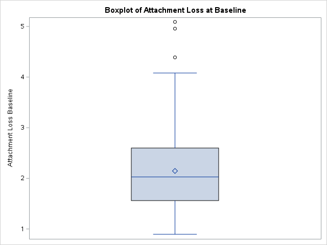

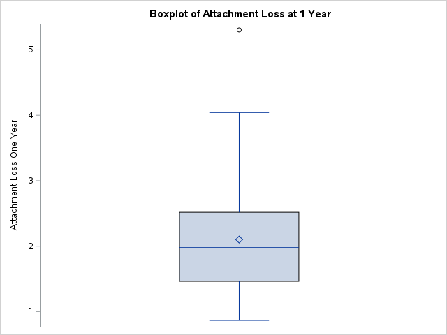

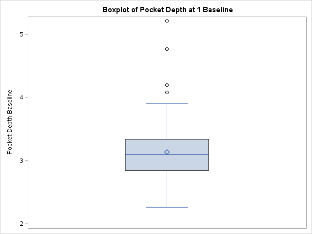

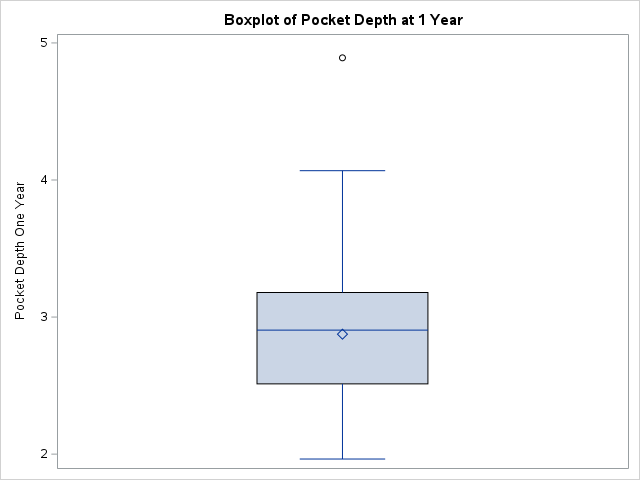

**log**

[output not shown]

Interestingly, there are 3 outliers for attachment loss at base, and only 1 after 1 year. Likewise, there are 4 outliers for pocket depth at base, but only 1 at 1 year. These outlier participants may have dropped out of the study or have missing values, or their values have returned to be within 3 SDs of the mean values. It will be important to assess this!

Outliers will be assessed statistically later using the jackknife residuals. A value will be considered an outlier if the jackknife residual is outside of the range of +/- 3, and has high leverage and influence in the model.

Back to top of tabset

**Variable Creation**

Since we have two timepoints of both attachment loss and pocket depth loss, it will make the most sense to create a change score for each measurement and use those as the dependent variable. This will make the analysis significantly easier to perform and understand/explain, while still being an accurate analysis.

**Note**

attachchange and pdchange are coded such that *higher scores signify a greater loss over time*

For example, for subject 101:

$$2.577(1 year)-2.43(base) = 0.14 5 (change in attachment loss)$$

Negative values mean that attachment loss/ pocket depth *IMPROVED* for that participant (i.e., they gained gum attachment back)

```sas
* Here we will create change scores for attachment loss and pocket depth;
DATA Proj1.data;
    SET Proj1.data;
    attachchange = attach1year - attachbase;
    pdchange = pd1year - pdbase;
    LABEL
    attachchange = "Attachment Loss Change"
    pdchange = "Pocket Depth Change";
    RUN;
```

And view the data set to make sure those change scores check out.

```sas
* View dataset;
PROC PRINT DATA = Proj1.data (OBS = 10);
  RUN;
```

**lst**

Boxplot of Pocket Depth at 1 Year

| Obs | id | trtgroup | gender | race | age | smoker | sites | attachbase | pdbase | attach1year | pd1year | attachchange | pdchange |
| --- | --- | --- | --- | --- | --- | --- | --- | --- | --- | --- | --- | --- | --- |
| 1 | 101 | Medium | Female | Asian | 44.57221082 | Smoker | 162 | 2.432098765 | 3.24691358 | 2.57764 | 3.40741 | 0.14554 | 0.16049 |
| 2 | 102 | High | Female | Asian | 35.57289528 | Smoker | 162 | 2.543209877 | 3.00617284 | . | . | . | . |
| 3 | 103 | Control | Female | Asian | 47.94524298 | Smoker | 144 | 2.881944444 | 3.118055556 | 3.07639 | 3.12500 | 0.19444 | 0.00694 |
| 4 | 104 | Low | Female | Asian | 55.17864476 | Smoker | 138 | 4.956521739 | 5.217391304 | 5.30435 | 4.89130 | 0.34783 | -0.32609 |
| 5 | 105 | Placebo | Female | African American | 43.79739904 | Smoker | 168 | 1.773809524 | 3.363095238 | 1.45238 | 2.89881 | -0.32143 | -0.46429 |
| 6 | 106 | Medium | Female | Asian | 42.14921287 | Smoker | 168 | 2.369047619 | 3.910714286 | 1.92262 | 3.08333 | -0.44643 | -0.82738 |
| 7 | 107 | Low | Female | Asian | 37.15811088 | Smoker | 156 | 3.544871795 | 3.897435897 | 2.83974 | 3.23718 | -0.70513 | -0.66026 |
| 8 | 108 | Control | Female | Asian | 67.41957563 | Smoker | 162 | 2.493827161 | 3.481481482 | 2.19136 | 3.08025 | -0.30247 | -0.40123 |
| 9 | 109 | High | Female | African American | 40.59137577 | Smoker | 156 | 1.92948718 | 3.301282051 | 1.62821 | 2.71154 | -0.30128 | -0.58974 |
| 10 | 110 | Placebo | Female | Asian | 49.2128679 | Smoker | 162 | 1.790123457 | 3.277777778 | 1.46296 | 2.41975 | -0.32716 | -0.85802 |

**log**

[output not shown]

Back to top of tabset

**Missingness**

Here we will investigate the missingness of the dataset

```sas
* Examine Missingness;
TITLE "Missingness";
PROC MEANS DATA = Proj1.data n nmiss;
    VAR _ALL_;
    RUN;
```

**lst**

Missingness

The MEANS Procedure

| Variable | Label | N | N Miss |
| --- | --- | --- | --- |
| id trtgroup gender race age smoker sites attachbase pdbase attach1year pd1year attachchange pdchange | ID Treatment Group Gender Race Age Smoking Status Sites Attachment Loss Baseline Pocket Depth Baseline Attachment Loss One Year Pocket Depth One Year Attachment Loss Change Pocket Depth Change | 130 130 130 130 129 129 130 130 130 103 103 103 103 | 0 0 0 0 1 1 0 0 0 27 27 27 27 |

**log**

[output not shown]

There is 1 missing value for age and smoking status, and 27 missing values for the one year measurements of attachment loss and pocket depth.

This is 27/130 = 20.77% of our sample size, quite large! We will still have 103 participants, which should be sufficient to run our analysis if there are 20-30 participants in each condition. Let’s check

```sas
* Break missing data down by treatment group;
TITLE "Missingness by Treatment Condition";
PROC MEANS DATA = Proj1.data n nmiss;
    CLASS trtgroup;
    VAR attachchange;
    RUN;
```

**lst**

Missingness by Treatment Condition

The MEANS Procedure

| Analysis Variable : attachchange Attachment Loss Change Treatment Group | Analysis Variable : attachchange Attachment Loss Change N Obs | Analysis Variable : attachchange Attachment Loss Change N | Analysis Variable : attachchange Attachment Loss Change N Miss |
| --- | --- | --- | --- |
| Placebo | 26 | 23 | 3 |
| Control | 26 | 23 | 3 |
| Low | 26 | 21 | 5 |
| Medium | 26 | 20 | 6 |
| High | 26 | 16 | 10 |

**log**

[output not shown]

There are only 16 participants in the high concentrations (5) group.

This could cause problems! We will either have to combine all the treatment conditions into one group, or perform some multiple imputations to handle the missing data. This will have to be noted in the discussion.

Let’s also examine if missinginess differs between genders.

```sas
* Break missing data down by gender;
TITLE "Missingness by Gender";
PROC MEANS DATA = Proj1.data n nmiss;
    CLASS gender;
    VAR attachchange;
    RUN;
```

**lst**

Missingness by Gender

The MEANS Procedure

| Analysis Variable : attachchange Attachment Loss Change Gender | Analysis Variable : attachchange Attachment Loss Change N Obs | Analysis Variable : attachchange Attachment Loss Change N | Analysis Variable : attachchange Attachment Loss Change N Miss |
| --- | --- | --- | --- |
| Male | 54 | 36 | 18 |
| Female | 76 | 67 | 9 |

**log**

[output not shown]

Males appear to have more missing values, so our data is Missing at Random (MAR).

See Multiple Imputation section for analysis with multiple imputation.

Back to top of tabset

## Descriptive Statistics

Here we will acquire the descriptive statistics of our data set and create Table 1.

```sas
* Generate Table 1;
TITLE "Table 1";
PROC TABULATE DATA=Proj1.data;
    CLASS trtgroup gender race smoker;
    VAR age sites attachbase attach1year pdbase pd1year attachchange pdchange;
    TABLE
        (gender race smoker)*(n) (age sites attachbase attach1year pdbase pd1year attachchange pdchange)*(n mean std min max),
        trtgroup ALL;
RUN;
```

**lst**

Table 1

[output not shown]

**log**

[output not shown]

## Preliminary Evaluation of Assumptions

Before we begin digging into the data, let’s take a closer look at the relationships between our variables.

We will first run a correlation matrix to assess the correlations between our IVs. Then we will explore any high correlations that which could affect our analysis.

Finally we will make histograms of attachment loss and pocket depth change to gauge whether they will be normally distributed or if we need to run some transformations.

**Correlation Matrix**

First we will begin by making a correlation matrix to assess whether any of our IVs are related to each other (multicollinearity). This will inform which variables to incorporate into the final model.

```sas
* Create and visualize the correlation matrix;
TITLE "Correlation Matrix";
ODS GRAPHICS ON;
PROC CORR DATA = Proj1.data PLOTS = MATRIX(HISTOGRAM);
    VAR age sites attachbase attach1year pdbase pd1year attachchange pdchange;
    RUN;
ODS GRAPHICS OFF;
```

**lst**

Correlation Matrix

The CORR Procedure

| 8 Variables: | age sites attachbase attach1year pdbase pd1year attachchange pdchange |
| --- | --- |

| Simple Statistics Variable | Simple Statistics N | Simple Statistics Mean | Simple Statistics Std Dev | Simple Statistics Sum | Simple Statistics Minimum | Simple Statistics Maximum | Simple Statistics Label |
| --- | --- | --- | --- | --- | --- | --- | --- |
| age | 129 | 49.94347 | 10.03233 | 6443 | 28.57221 | 74.53251 | Age |
| sites | 130 | 157.50769 | 11.34125 | 20476 | 114.00000 | 168.00000 | Sites |
| attachbase | 130 | 2.14608 | 0.79705 | 278.98979 | 0.89506 | 5.08929 | Attachment Loss Baseline |
| attach1year | 103 | 2.10139 | 0.77188 | 216.44302 | 0.86538 | 5.30435 | Attachment Loss One Year |
| pdbase | 130 | 3.13837 | 0.43672 | 407.98821 | 2.26282 | 5.21739 | Pocket Depth Baseline |
| pd1year | 103 | 2.87516 | 0.48755 | 296.14175 | 1.96429 | 4.89130 | Pocket Depth One Year |
| attachchange | 103 | -0.09945 | 0.27603 | -10.24346 | -1.04762 | 0.45238 | Attachment Loss Change |
| pdchange | 103 | -0.29435 | 0.26761 | -30.31849 | -0.85802 | 0.45513 | Pocket Depth Change |

| Pearson Correlation Coefficients Prob > \|r\| under H0: Rho=0 Number of Observations | Pearson Correlation Coefficients Prob > \|r\| under H0: Rho=0 Number of Observations age | Pearson Correlation Coefficients Prob > \|r\| under H0: Rho=0 Number of Observations sites | Pearson Correlation Coefficients Prob > \|r\| under H0: Rho=0 Number of Observations attachbase | Pearson Correlation Coefficients Prob > \|r\| under H0: Rho=0 Number of Observations attach1year | Pearson Correlation Coefficients Prob > \|r\| under H0: Rho=0 Number of Observations pdbase | Pearson Correlation Coefficients Prob > \|r\| under H0: Rho=0 Number of Observations pd1year | Pearson Correlation Coefficients Prob > \|r\| under H0: Rho=0 Number of Observations attachchange | Pearson Correlation Coefficients Prob > \|r\| under H0: Rho=0 Number of Observations pdchange |
| --- | --- | --- | --- | --- | --- | --- | --- | --- |
| age Age | 1.00000 129 | -0.11266 0.2037 129 | 0.12162 0.1698 129 | 0.08605 0.3898 102 | -0.11097 0.2106 129 | -0.12526 0.2097 102 | -0.17458 0.0793 102 | -0.07422 0.4585 102 |
| sites Sites | -0.11266 0.2037 129 | 1.00000 130 | -0.39708 <.0001 130 | -0.36885 0.0001 103 | -0.16634 0.0586 130 | -0.18852 0.0565 103 | 0.16209 0.1019 103 | -0.04812 0.6293 103 |
| attachbase Attachment Loss Baseline | 0.12162 0.1698 129 | -0.39708 <.0001 130 | 1.00000 130 | 0.94556 <.0001 103 | 0.58869 <.0001 130 | 0.54983 <.0001 103 | -0.41437 <.0001 103 | -0.03676 0.7124 103 |
| attach1year Attachment Loss One Year | 0.08605 0.3898 102 | -0.36885 0.0001 103 | 0.94556 <.0001 103 | 1.00000 103 | 0.60498 <.0001 103 | 0.66049 <.0001 103 | -0.09561 0.3367 103 | 0.15128 0.1272 103 |
| pdbase Pocket Depth Baseline | -0.11097 0.2106 129 | -0.16634 0.0586 130 | 0.58869 <.0001 130 | 0.60498 <.0001 103 | 1.00000 130 | 0.84327 <.0001 103 | -0.13472 0.1749 103 | -0.20267 0.0401 103 |
| pd1year Pocket Depth One Year | -0.12526 0.2097 102 | -0.18852 0.0565 103 | 0.54983 <.0001 103 | 0.66049 <.0001 103 | 0.84327 <.0001 103 | 1.00000 103 | 0.16531 0.0952 103 | 0.35543 0.0002 103 |
| attachchange Attachment Loss Change | -0.17458 0.0793 102 | 0.16209 0.1019 103 | -0.41437 <.0001 103 | -0.09561 0.3367 103 | -0.13472 0.1749 103 | 0.16531 0.0952 103 | 1.00000 103 | 0.53546 <.0001 103 |
| pdchange Pocket Depth Change | -0.07422 0.4585 102 | -0.04812 0.6293 103 | -0.03676 0.7124 103 | 0.15128 0.1272 103 | -0.20267 0.0401 103 | 0.35543 0.0002 103 | 0.53546 <.0001 103 | 1.00000 103 |

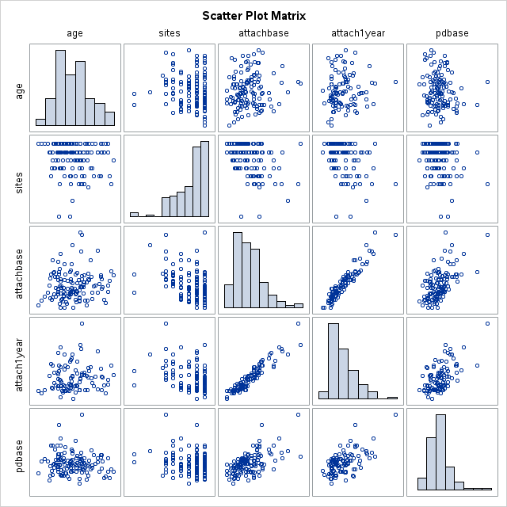

**log**

[output not shown]

Visually, we can see a cluster of high positive correlations between all of attachment loss and pocket depth at baseline and 1 year. This makes sense, as all measurements were taken from the same sites in the gums. This will be explored later (See Exploratory Data Analysis - Dependent Variables)

Back to top of tabset

**Normality of Dependent Variables**

Here we will simply plot the histograms of attachment loss and pocket depth changes scores, to assess if they appear normally distributed or if we will have to perform a transformation of some kind.

```sas
* Assess Normality of Dependent Variables (attachchange, pdchange);
* Note: Here we would use the Kolmogorov-Smirnov test, since our sample size is > 50
    if the sample size was < 50 you would use Shapiro Wilks test;
TITLE "Normality Assesment";
PROC UNIVARIATE DATA = Proj1.data;
    VAR attachchange pdchange;
    HISTOGRAM attachchange pdchange / NORMAL;
    QQPLOT attachchange pdchange / NORMAL (MU=EST SIGMA = EST);
    RUN;
```

**lst**

Normality Assesment

The UNIVARIATE Procedure

Variable: attachchange (Attachment Loss Change)

| Moments |  |  |  |
| --- | --- | --- | --- |
| N | 103 | Sum Weights | 103 |
| Mean | -0.099451 | Sum Observations | -10.243457 |
| Std Deviation | 0.27603039 | Variance | 0.07619277 |
| Skewness | -0.7927997 | Kurtosis | 1.03785174 |
| Uncorrected SS | 8.79038543 | Corrected SS | 7.77166295 |
| Coeff Variation | -277.55404 | Std Error Mean | 0.02719808 |

| Basic Statistical Measures Location | Basic Statistical Measures Location | Basic Statistical Measures Variability | Basic Statistical Measures Variability |
| --- | --- | --- | --- |
| Mean | -0.09945 | Std Deviation | 0.27603 |
| Median | -0.06790 | Variance | 0.07619 |
| Mode | -0.18519 | Range | 1.50000 |
|  |  | Interquartile Range | 0.36684 |

Note: The mode displayed is the smallest of 3 modes with a count of 2.

| Tests for Location: Mu0=0 Test | Tests for Location: Mu0=0 Statistic | Tests for Location: Mu0=0 Statistic | Tests for Location: Mu0=0 p Value | Tests for Location: Mu0=0 p Value |
| --- | --- | --- | --- | --- |
| Student's t | t | -3.65655 | Pr > \|t\| | 0.0004 |
| Sign | M | -12.5 | Pr >= \|M\| | 0.0176 |
| Signed Rank | S | -926.5 | Pr >= \|S\| | 0.0020 |

| Quantiles (Definition 5) Level | Quantiles (Definition 5) Quantile |
| --- | --- |
| 100% Max | 0.4523810 |
| 99% | 0.3478261 |
| 95% | 0.3148148 |
| 90% | 0.2222222 |
| 75% Q3 | 0.0952381 |
| 50% Median | -0.0679012 |
| 25% Q1 | -0.2716049 |
| 10% | -0.4487179 |
| 5% | -0.5434783 |
| 1% | -0.9008889 |
| 0% Min | -1.0476190 |

| Extreme Observations Lowest Value | Extreme Observations Lowest Obs | Extreme Observations Highest Value | Extreme Observations Highest Obs |
| --- | --- | --- | --- |
| -1.047619 | 67 | 0.320513 | 16 |
| -0.900889 | 44 | 0.327160 | 64 |
| -0.810000 | 46 | 0.339286 | 34 |
| -0.705128 | 7 | 0.347826 | 4 |
| -0.598765 | 43 | 0.452381 | 13 |

| Missing Values Missing Value | Missing Values Count | Missing Values Percent Of All Obs | Missing Values Percent Of Missing Obs |
| --- | --- | --- | --- |
| . | 27 | 20.77 | 100.00 |

Normality Assesment

The UNIVARIATE Procedure

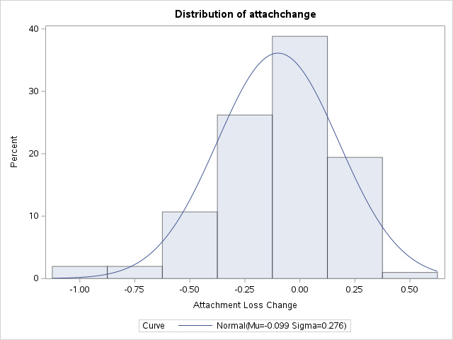

Normality Assesment

The UNIVARIATE Procedure

Fitted Normal Distribution for attachchange (Attachment Loss Change)

| Parameters for Normal Distribution Parameter | Parameters for Normal Distribution Symbol | Parameters for Normal Distribution Estimate |
| --- | --- | --- |
| Mean | Mu | -0.09945 |
| Std Dev | Sigma | 0.27603 |

| Goodness-of-Fit Tests for Normal Distribution Test | Goodness-of-Fit Tests for Normal Distribution Statistic | Goodness-of-Fit Tests for Normal Distribution Statistic | Goodness-of-Fit Tests for Normal Distribution p Value | Goodness-of-Fit Tests for Normal Distribution p Value |
| --- | --- | --- | --- | --- |
| Kolmogorov-Smirnov | D | 0.08091601 | Pr > D | 0.095 |
| Cramer-von Mises | W-Sq | 0.12605262 | Pr > W-Sq | 0.049 |
| Anderson-Darling | A-Sq | 0.79367755 | Pr > A-Sq | 0.040 |

| Quantiles for Normal Distribution Percent | Quantiles for Normal Distribution Quantile Observed | Quantiles for Normal Distribution Quantile Estimated |
| --- | --- | --- |
| 1.0 | -0.90089 | -0.74159 |
| 5.0 | -0.54348 | -0.55348 |
| 10.0 | -0.44872 | -0.45320 |
| 25.0 | -0.27160 | -0.28563 |
| 50.0 | -0.06790 | -0.09945 |
| 75.0 | 0.09524 | 0.08673 |
| 90.0 | 0.22222 | 0.25430 |
| 95.0 | 0.31481 | 0.35458 |
| 99.0 | 0.34783 | 0.54269 |

Normality Assesment

The UNIVARIATE Procedure

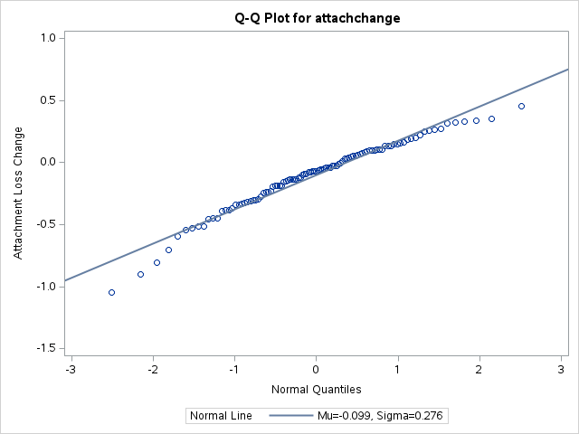

Normality Assesment

The UNIVARIATE Procedure

Variable: pdchange (Pocket Depth Change)

| Moments |  |  |  |
| --- | --- | --- | --- |
| N | 103 | Sum Weights | 103 |
| Mean | -0.2943543 | Sum Observations | -30.318488 |
| Std Deviation | 0.2676105 | Variance | 0.07161538 |
| Skewness | 0.07023632 | Kurtosis | -0.2191411 |
| Uncorrected SS | 16.2291445 | Corrected SS | 7.30476874 |
| Coeff Variation | -90.914434 | Std Error Mean | 0.02636845 |

| Basic Statistical Measures Location | Basic Statistical Measures Location | Basic Statistical Measures Variability | Basic Statistical Measures Variability |
| --- | --- | --- | --- |
| Mean | -0.29435 | Std Deviation | 0.26761 |
| Median | -0.28395 | Variance | 0.07162 |
| Mode | -0.50000 | Range | 1.31315 |
|  |  | Interquartile Range | 0.38448 |

Note: The mode displayed is the smallest of 3 modes with a count of 2.

| Tests for Location: Mu0=0 Test | Tests for Location: Mu0=0 Statistic | Tests for Location: Mu0=0 Statistic | Tests for Location: Mu0=0 p Value | Tests for Location: Mu0=0 p Value |
| --- | --- | --- | --- | --- |
| Student's t | t | -11.1631 | Pr > \|t\| | <.0001 |
| Sign | M | -35.5 | Pr >= \|M\| | <.0001 |
| Signed Rank | S | -2352 | Pr >= \|S\| | <.0001 |

| Quantiles (Definition 5) Level | Quantiles (Definition 5) Quantile |
| --- | --- |
| 100% Max | 0.4551282 |
| 99% | 0.2976190 |
| 95% | 0.1604938 |
| 90% | 0.0476190 |
| 75% Q3 | -0.0952381 |
| 50% Median | -0.2839506 |
| 25% Q1 | -0.4797178 |
| 10% | -0.6845238 |
| 5% | -0.7283951 |
| 1% | -0.8452381 |
| 0% Min | -0.8580247 |

| Extreme Observations Lowest Value | Extreme Observations Lowest Obs | Extreme Observations Highest Value | Extreme Observations Highest Obs |
| --- | --- | --- | --- |
| -0.858025 | 10 | 0.160494 | 89 |
| -0.845238 | 18 | 0.160714 | 130 |
| -0.827381 | 6 | 0.174638 | 21 |
| -0.759259 | 66 | 0.297619 | 37 |
| -0.749094 | 54 | 0.455128 | 99 |

| Missing Values Missing Value | Missing Values Count | Missing Values Percent Of All Obs | Missing Values Percent Of Missing Obs |
| --- | --- | --- | --- |
| . | 27 | 20.77 | 100.00 |

Normality Assesment

The UNIVARIATE Procedure

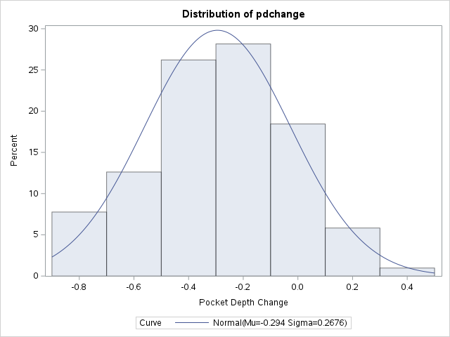

Normality Assesment

The UNIVARIATE Procedure

Fitted Normal Distribution for pdchange (Pocket Depth Change)

| Parameters for Normal Distribution Parameter | Parameters for Normal Distribution Symbol | Parameters for Normal Distribution Estimate |
| --- | --- | --- |
| Mean | Mu | -0.29435 |
| Std Dev | Sigma | 0.267611 |

| Goodness-of-Fit Tests for Normal Distribution Test | Goodness-of-Fit Tests for Normal Distribution Statistic | Goodness-of-Fit Tests for Normal Distribution Statistic | Goodness-of-Fit Tests for Normal Distribution p Value | Goodness-of-Fit Tests for Normal Distribution p Value |
| --- | --- | --- | --- | --- |
| Kolmogorov-Smirnov | D | 0.04137085 | Pr > D | >0.150 |
| Cramer-von Mises | W-Sq | 0.02560441 | Pr > W-Sq | >0.250 |
| Anderson-Darling | A-Sq | 0.19521495 | Pr > A-Sq | >0.250 |

| Quantiles for Normal Distribution Percent | Quantiles for Normal Distribution Quantile Observed | Quantiles for Normal Distribution Quantile Estimated |
| --- | --- | --- |
| 1.0 | -0.84524 | -0.91691 |
| 5.0 | -0.72840 | -0.73453 |
| 10.0 | -0.68452 | -0.63731 |
| 25.0 | -0.47972 | -0.47485 |
| 50.0 | -0.28395 | -0.29435 |
| 75.0 | -0.09524 | -0.11385 |
| 90.0 | 0.04762 | 0.04860 |
| 95.0 | 0.16049 | 0.14583 |
| 99.0 | 0.29762 | 0.32820 |

Normality Assesment

The UNIVARIATE Procedure

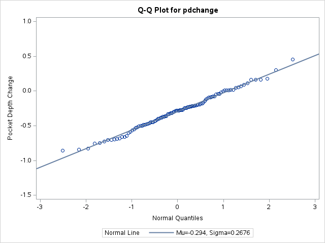

**log**

[output not shown]

#### Conclusion

Both attachment loss and pocket depth change appear to be normally distributed and will not need to be transformed. Attachment loss change is slightly left-tailed but this could be due to outliers, or may just not impact the analysis.

Back to top of tabset

## Exploratory Data Analysis

Here I will plot the data and perform a number of simple linear regressions to examine relationships between variables in order to determine which covariates to include in the model.

**Primary Explanatory Variable**

**5 Treatment Groups**

Let’s examine if there appears to be a difference in the average attachment loss and pocket depth change according to treatment level

```sas
* Boxplot of attachchange vs treatment condition;
TITLE "Primary Attachment Loss Change by Treatment Condition";
PROC SGPLOT DATA = Proj1.data;
    VBOX attachchange / CATEGORY = trtgroup;
    RUN;

* Boxplot of pdchange vs treatment condition;
TITLE "Primary Pocket Depth Change by Treatment Condition";
PROC SGPLOT DATA = Proj1.data;
    VBOX pdchange / CATEGORY = trtgroup;
    RUN;
```

**lst**

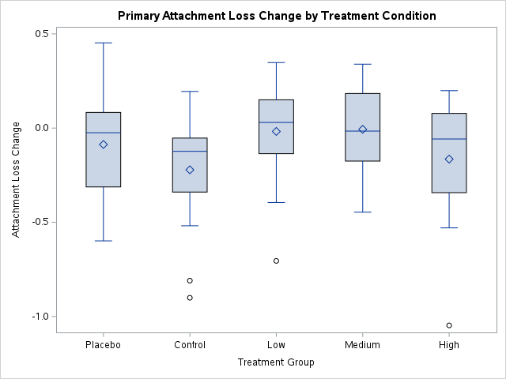

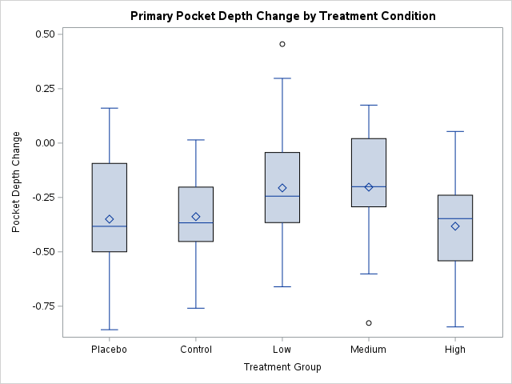

**log**

[output not shown]

#### Attachment Loss Change

Visually, there does not appear to be a difference between the treatment group levels (low, medium, high concentration gel) compared to each other. Additionally, there does not seem to be a difference between the treatment groups and the placebo for attachment loss change.

Back to top of tabset

**Covariates**

Now we will exlore the relationships between our potential covariates and attachment loss and pocket depth change

**Gender**

It is conceivable that there are sex differences in regards to gum health. Let’s examine if there is a difference in attachment loss or pocket depth change based on gender

```sas
* Create boxplot of gender vs attachmnent loss change;
TITLE "Boxplot of Gender vs Attachment Loss Change";
PROC SGPLOT DATA = Proj1.data;
    VBOX attachchange / CATEGORY = gender;
    RUN;

* Create boxplot of gender vs pocket depth change;
TITLE "Boxplot of Gender vs Pocket Depth Change";
PROC SGPLOT DATA = Proj1.data;
    VBOX pdchange / CATEGORY = gender;
    RUN;

* Note: Males may have more pocket depth change than females
    Run a t-test to assess;
PROC TTEST DATA = Proj1.data;
    CLASS gender;
    VAR pdchange;
    RUN;
```

**lst**

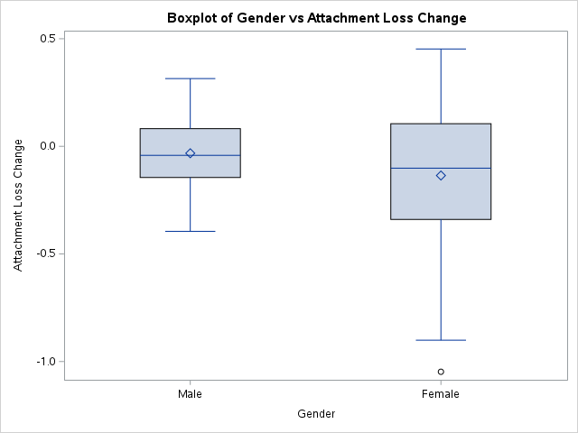

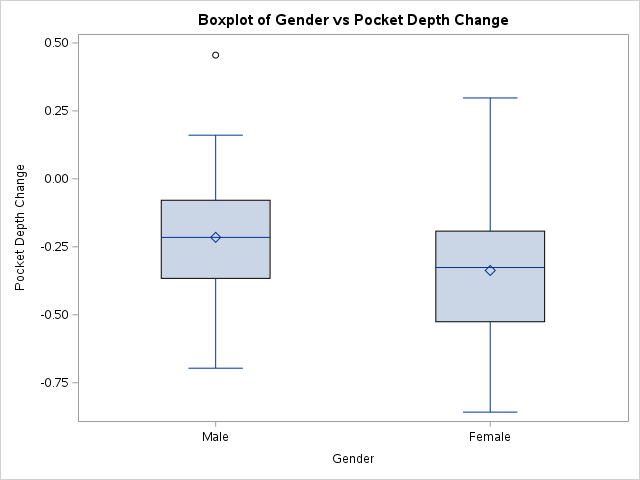

Boxplot of Gender vs Pocket Depth Change

The TTEST Procedure

Variable: pdchange (Pocket Depth Change)

| gender | Method | N | Mean | Std Dev | Std Err | Minimum | Maximum |
| --- | --- | --- | --- | --- | --- | --- | --- |
| Male |  | 36 | -0.2151 | 0.2362 | 0.0394 | -0.6964 | 0.4551 |
| Female |  | 67 | -0.3369 | 0.2754 | 0.0336 | -0.8580 | 0.2976 |
| Diff (1-2) | Pooled |  | 0.1219 | 0.2625 | 0.0542 |  |  |
| Diff (1-2) | Satterthwaite |  | 0.1219 |  | 0.0518 |  |  |

| gender | Method | Mean | 95% CL Mean |  | Std Dev | 95% CL Std Dev |  |
| --- | --- | --- | --- | --- | --- | --- | --- |
| Male |  | -0.2151 | -0.2950 | -0.1352 | 0.2362 | 0.1916 | 0.3081 |
| Female |  | -0.3369 | -0.4041 | -0.2698 | 0.2754 | 0.2353 | 0.3319 |
| Diff (1-2) | Pooled | 0.1219 | 0.0143 | 0.2295 | 0.2625 | 0.2307 | 0.3044 |
| Diff (1-2) | Satterthwaite | 0.1219 | 0.0188 | 0.2249 |  |  |  |

| Method | Variances | DF | t Value | Pr > \|t\| |
| --- | --- | --- | --- | --- |
| Pooled | Equal | 101 | 2.25 | 0.0268 |
| Satterthwaite | Unequal | 81.683 | 2.35 | 0.0210 |

| Equality of Variances Method | Equality of Variances Num DF | Equality of Variances Den DF | Equality of Variances F Value | Equality of Variances Pr > F |
| --- | --- | --- | --- | --- |
| Folded F | 66 | 35 | 1.36 | 0.3250 |

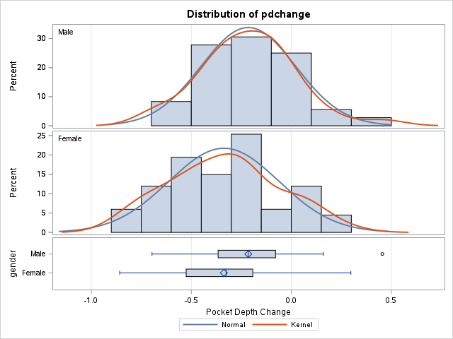

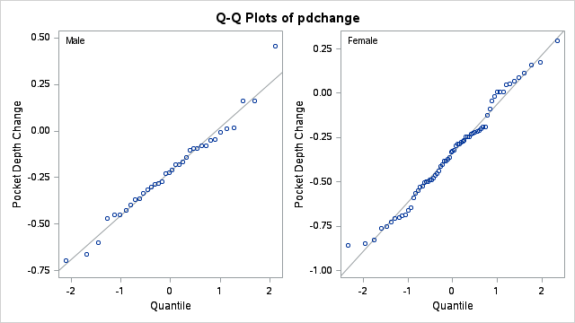

**log**

[output not shown]

**Therefore I will include gender as a covariate in the analysis!**

Back to top of tabset

**Age**

```sas
* Create scatterplot of age vs attachment loss change;
TITLE "Age vs Attachment Loss Change";
PROC SGPLOT DATA = Proj1.data;
    SCATTER X = age y = attachchange / GROUP = trtgroup;
    RUN;

* Create scatterplot of sites vs pocket depth change;
TITLE "Age vs Pocket Depth Change";
PROC SGPLOT DATA = Proj1.data;
    SCATTER X = age y = pdchange / GROUP = trtgroup;
    RUN;
```

**lst**

<!DOCTYPE html>

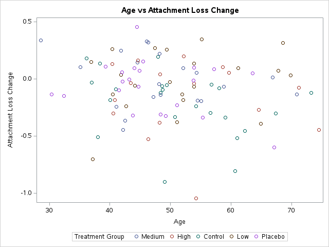

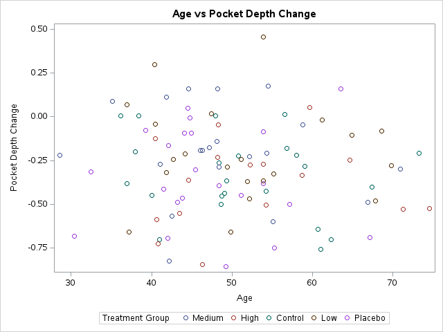

**log**

```
41                                                         The SAS System                      Friday, December 19, 2025 03:16:00 AM

427        ods listing close;ods html5 (id=saspy_internal) file=_tomods1 options(bitmap_mode='inline') device=svg style=HTMLBlue;
427      ! ods graphics on / outputfmt=png;
428
429        * Create scatterplot of age vs attachment loss change;
430        TITLE "Age vs Attachment Loss Change";
431        PROC SGPLOT DATA = Proj1.data;
432         SCATTER X = age y = attachchange / GROUP = trtgroup;
433         RUN;
434
435        * Create scatterplot of sites vs pocket depth change;
436        TITLE "Age vs Pocket Depth Change";
437        PROC SGPLOT DATA = Proj1.data;
438         SCATTER X = age y = pdchange / GROUP = trtgroup;
439         RUN;
440
441
442        ods html5 (id=saspy_internal) close;ods listing;
443
42                                                         The SAS System                      Friday, December 19, 2025 03:16:00 AM

444
```

There does not appear to be any kind of linear relationship between age and attachment loss change or pocket depth change. I will run a model where I include age, but it will likely be removed in the final model.

Back to top of tabset

**Sites**

Is there any relationship between the number of sites measured from and attachment loss change or pocket depth change (e.g. a lower number of sites could lead to less accurate readings)? If so this could be something to include in our data analysis

```sas
* Create scatterplot of sites vs attachment loss change;
TITLE "Sites vs Attachment Loss Change";
PROC SGPLOT DATA = Proj1.data;
    SCATTER X = sites y = attachchange / GROUP = trtgroup;
    RUN;

* Create scatterplot of sites vs pocket depth change;
TITLE "Sites vs Pocket Depth Change";
PROC SGPLOT DATA = Proj1.data;
    SCATTER X = sites y = pdchange / GROUP = trtgroup;
    RUN;
```

**lst**

<!DOCTYPE html>

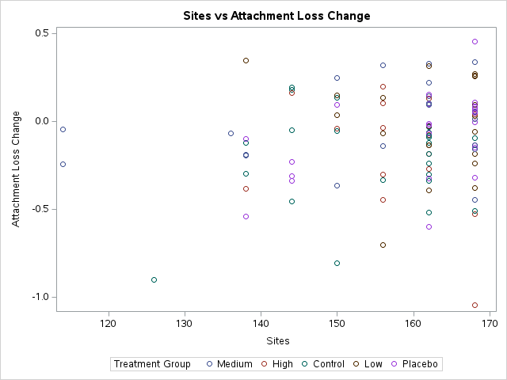

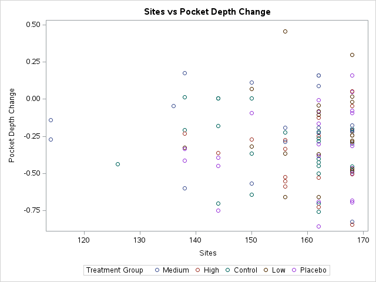

**log**

```
43                                                         The SAS System                      Friday, December 19, 2025 03:16:00 AM

447        ods listing close;ods html5 (id=saspy_internal) file=_tomods1 options(bitmap_mode='inline') device=svg style=HTMLBlue;
447      ! ods graphics on / outputfmt=png;
448
449        * Create scatterplot of sites vs attachment loss change;
450        TITLE "Sites vs Attachment Loss Change";
451        PROC SGPLOT DATA = Proj1.data;
452         SCATTER X = sites y = attachchange / GROUP = trtgroup;
453         RUN;
454
455        * Create scatterplot of sites vs pocket depth change;
456        TITLE "Sites vs Pocket Depth Change";
457        PROC SGPLOT DATA = Proj1.data;
458         SCATTER X = sites y = pdchange / GROUP = trtgroup;
459         RUN;
460
461
462        ods html5 (id=saspy_internal) close;ods listing;
463
44                                                         The SAS System                      Friday, December 19, 2025 03:16:00 AM

464
```

There does not seem to be a dramatic difference in attachment loss or pocket depth change based on the number of sites measured from. It’s a bit hard to tell with those two low site subjects, but the points are similar enough to the rest of the dataset that I do not think we have to worry about site number in our analysis.

Back to top of tabset

**Race**

```sas
* Create boxplot of race vs attachment loss change;
TITLE "Race vs Attachment Loss Change";
PROC SGPLOT DATA = Proj1.data;
    VBOX attachchange / CATEGORY = race;
    RUN;

* Create boxplot of race vs pocket depth change;
TITLE "Race vs Pocket Depth Change";
PROC SGPLOT DATA = Proj1.data;
    VBOX pdchange / CATEGORY = race;
    RUN;
```

**lst**

<!DOCTYPE html>

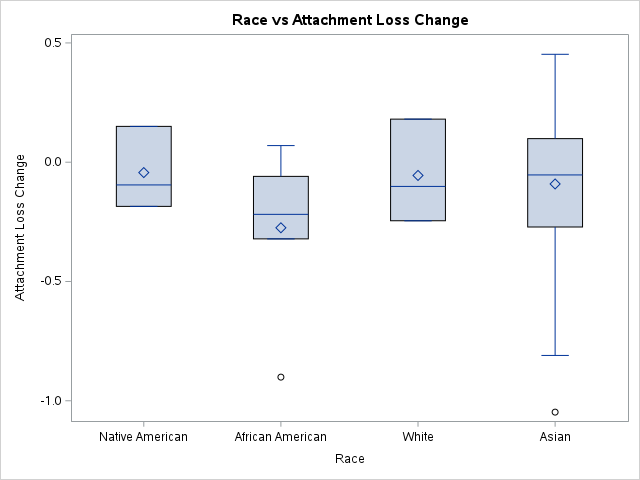

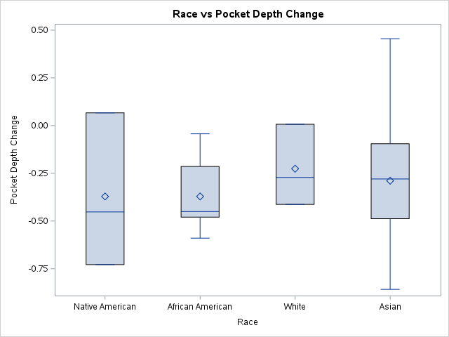

**log**

```
45                                                         The SAS System                      Friday, December 19, 2025 03:16:00 AM

467        ods listing close;ods html5 (id=saspy_internal) file=_tomods1 options(bitmap_mode='inline') device=svg style=HTMLBlue;
467      ! ods graphics on / outputfmt=png;
468
469        * Create boxplot of race vs attachment loss change;
470        TITLE "Race vs Attachment Loss Change";
471        PROC SGPLOT DATA = Proj1.data;
472         VBOX attachchange / CATEGORY = race;
473         RUN;
474
475        * Create boxplot of race vs pocket depth change;
476        TITLE "Race vs Pocket Depth Change";
477        PROC SGPLOT DATA = Proj1.data;
478         VBOX pdchange / CATEGORY = race;
479         RUN;
480
481
482        ods html5 (id=saspy_internal) close;ods listing;
483
46                                                         The SAS System                      Friday, December 19, 2025 03:16:00 AM

484
```

Back to top of tabset

**Smoking Status**

Whether the participant is a smoker or not likely has a dramatic effect on gum health. Let’s assess

```sas
TITLE "Smoking Status vs Attachment Loss Change";
PROC SGPLOT DATA = Proj1.data;
    VBOX attachchange / CATEGORY = smoker;
    RUN;

* Create boxplot of smoking status vs pocket depth change;
TITLE "Smoking Status vs Pocket Depth Change";
PROC SGPLOT DATA = Proj1.data;
    VBOX pdchange / CATEGORY = smoker;
    RUN;
```

**lst**

<!DOCTYPE html>

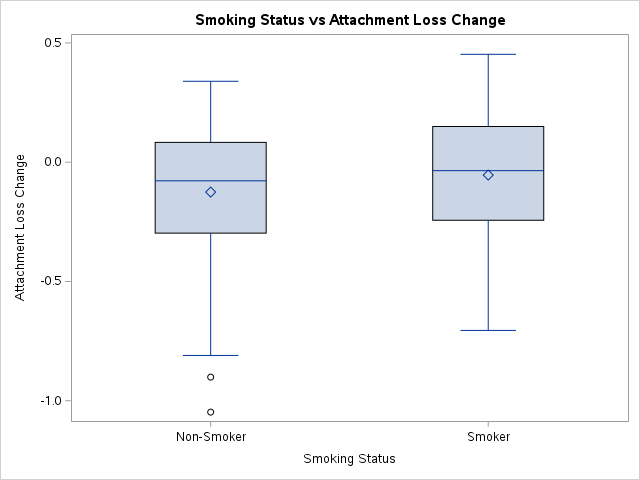

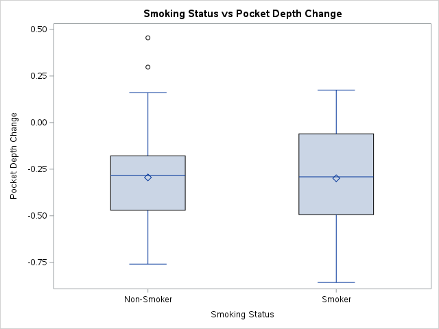

**log**

```
47                                                         The SAS System                      Friday, December 19, 2025 03:16:00 AM

487        ods listing close;ods html5 (id=saspy_internal) file=_tomods1 options(bitmap_mode='inline') device=svg style=HTMLBlue;
487      ! ods graphics on / outputfmt=png;
488
489        TITLE "Smoking Status vs Attachment Loss Change";
490        PROC SGPLOT DATA = Proj1.data;
491         VBOX attachchange / CATEGORY = smoker;
492         RUN;
493
494        * Create boxplot of smoking status vs pocket depth change;
495        TITLE "Smoking Status vs Pocket Depth Change";
496        PROC SGPLOT DATA = Proj1.data;
497         VBOX pdchange / CATEGORY = smoker;
498         RUN;
499
500
501        ods html5 (id=saspy_internal) close;ods listing;
502
48                                                         The SAS System                      Friday, December 19, 2025 03:16:00 AM

503
```

There does not appear to be any difference in attachment loss or pocket depth change based on smoking status. I will test a model with smoking status included, but it will likely be dropped in the final model.

Back to top of tabset

**Summary**

#### Gender

Gender is related to attachment loss and pocket depth change, and as such will be included in the final model.

#### Supressor / Counfound Variables

A model will be tested with all covariates to assess for possible suppressor / confound variables. But the other potential covariates of race, age, sites, and smoking status were not related to attachment loss or pocket depth change by themselves.

Back to top of tabset

# Data Analysis

Now we can perform the actual analysis!

The clinical hypothesis for this study is that average pocket depth and attachment loss in participants who applied the gel will be lower compared to participants who did not.

The statistical hypotheses are:

• Null Hypothesis:

$$H_0: μ_{placebo} = μ_{no treatment} = μ_{low} = μ_{medium} = μ_{high}$$

The average pocket depth and attachment loss for all conditions will be equal to each other.

• Alternative Hypothesis:

$$H_A: μ_{placebo} \neq μ_{no treatment} \neq μ_{low} \neq μ_{medium} \neq μ_{high}$$

At least one of the groups will have different average pocket depth or attachment loss.

## Running the Model

For ease of interpretation I will be performing this analysis as two separate linear regressions, one for each outcome variable of either attachment loss or pocket depth change. I will begin with a simple linear regression only including the PEV and either attachment loss change or pocket depth change.

**Attachment Loss Change**

We start by constructing a model with attachment loss change as the dependent variable, and treatment group as the independent variable.

First we need to create the dummy variables needed for these analyses.

```sas
* Create Dummy Variables;
TITLE "Create Dummy Variables";
DATA Proj1.data;
    SET Proj1.data;
    IF trtgroup ne . THEN DO;
        placebo = (trtgroup = 1);
        control = (trtgroup = 2);
        low     = (trtgroup = 3);
        medium  = (trtgroup = 4);
        high    = (trtgroup = 5);
    END;
RUN;

* Check Dummy Variables Created Correctly;
PROC PRINT DATA = Proj1.data (OBS = 6);
    RUN;
```

**lst**

<!DOCTYPE html>

Create Dummy Variables

| Obs | id | trtgroup | gender | race | age | smoker | sites | attachbase | pdbase | attach1year | pd1year | attachchange | pdchange | placebo | control | low | medium | high |
| --- | --- | --- | --- | --- | --- | --- | --- | --- | --- | --- | --- | --- | --- | --- | --- | --- | --- | --- |
| 1 | 101 | Medium | Female | Asian | 44.57221082 | Smoker | 162 | 2.432098765 | 3.24691358 | 2.57764 | 3.40741 | 0.14554 | 0.16049 | 0 | 0 | 0 | 1 | 0 |
| 2 | 102 | High | Female | Asian | 35.57289528 | Smoker | 162 | 2.543209877 | 3.00617284 | . | . | . | . | 0 | 0 | 0 | 0 | 1 |
| 3 | 103 | Control | Female | Asian | 47.94524298 | Smoker | 144 | 2.881944444 | 3.118055556 | 3.07639 | 3.12500 | 0.19444 | 0.00694 | 0 | 1 | 0 | 0 | 0 |
| 4 | 104 | Low | Female | Asian | 55.17864476 | Smoker | 138 | 4.956521739 | 5.217391304 | 5.30435 | 4.89130 | 0.34783 | -0.32609 | 0 | 0 | 1 | 0 | 0 |
| 5 | 105 | Placebo | Female | African American | 43.79739904 | Smoker | 168 | 1.773809524 | 3.363095238 | 1.45238 | 2.89881 | -0.32143 | -0.46429 | 1 | 0 | 0 | 0 | 0 |
| 6 | 106 | Medium | Female | Asian | 42.14921287 | Smoker | 168 | 2.369047619 | 3.910714286 | 1.92262 | 3.08333 | -0.44643 | -0.82738 | 0 | 0 | 0 | 1 | 0 |

**log**

```
49                                                         The SAS System                      Friday, December 19, 2025 03:16:00 AM

506        ods listing close;ods html5 (id=saspy_internal) file=_tomods1 options(bitmap_mode='inline') device=svg style=HTMLBlue;
506      ! ods graphics on / outputfmt=png;
507
508        * Create Dummy Variables;
509        TITLE "Create Dummy Variables";
510        DATA Proj1.data;
511            SET Proj1.data;
512            IF trtgroup ne . THEN DO;
513                placebo = (trtgroup = 1);
514                control = (trtgroup = 2);
515                low     = (trtgroup = 3);
516                medium  = (trtgroup = 4);
517                high    = (trtgroup = 5);
518         END;
519        RUN;
520
521        * Check Dummy Variables Created Correctly;
522        PROC PRINT DATA = Proj1.data (OBS = 6);
523         RUN;
524
525
526        ods html5 (id=saspy_internal) close;ods listing;
527
50                                                         The SAS System                      Friday, December 19, 2025 03:16:00 AM

528
```

```sas
* Run regression of attachment loss by treatment condition with control as reference;
TITLE "SLR of Attachment Loss Change by Treatment Condition - Control as Reference";
PROC REG DATA = Proj1.data;
    MODEL attachchange = placebo low medium high;
    RUN;
```

**lst**

<!DOCTYPE html>

SLR of Attachment Loss Change by Treatment Condition - Control as Reference

The REG Procedure

Model: MODEL1

Dependent Variable: attachchange Attachment Loss Change

| Number of Observations Read | 130 |
| --- | --- |
| Number of Observations Used | 103 |
| Number of Observations with Missing Values | 27 |

| Analysis of Variance Source | Analysis of Variance DF | Analysis of Variance Sum of Squares | Analysis of Variance Mean Square | Analysis of Variance F Value | Analysis of Variance Pr > F |
| --- | --- | --- | --- | --- | --- |
| Model | 4 | 0.72806 | 0.18202 | 2.53 | 0.0451 |
| Error | 98 | 7.04360 | 0.07187 |  |  |
| Corrected Total | 102 | 7.77166 |  |  |  |

| Root MSE | 0.26809 | R-Square | 0.0937 |
| --- | --- | --- | --- |
| Dependent Mean | -0.09945 | Adj R-Sq | 0.0567 |
| Coeff Var | -269.57211 |  |  |

| Parameter Estimates Variable | Parameter Estimates Label | Parameter Estimates DF | Parameter Estimates Parameter Estimate | Parameter Estimates Standard Error | Parameter Estimates t Value | Parameter Estimates Pr > \|t\| |
| --- | --- | --- | --- | --- | --- | --- |
| Intercept | Intercept | 1 | -0.22169 | 0.05590 | -3.97 | 0.0001 |
| placebo |  | 1 | 0.13462 | 0.07906 | 1.70 | 0.0918 |
| low |  | 1 | 0.20388 | 0.08092 | 2.52 | 0.0134 |
| medium |  | 1 | 0.21514 | 0.08197 | 2.62 | 0.0101 |
| high |  | 1 | 0.05690 | 0.08728 | 0.65 | 0.5159 |

SLR of Attachment Loss Change by Treatment Condition - Control as Reference

The REG Procedure

Model: MODEL1

Dependent Variable: attachchange Attachment Loss Change

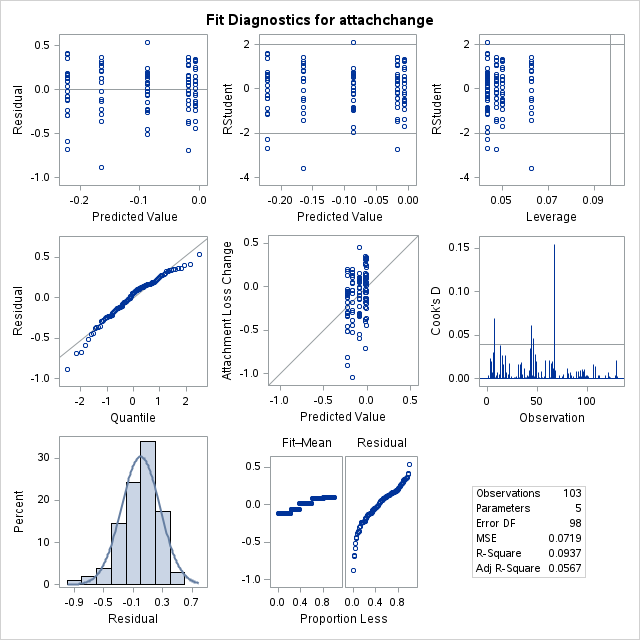

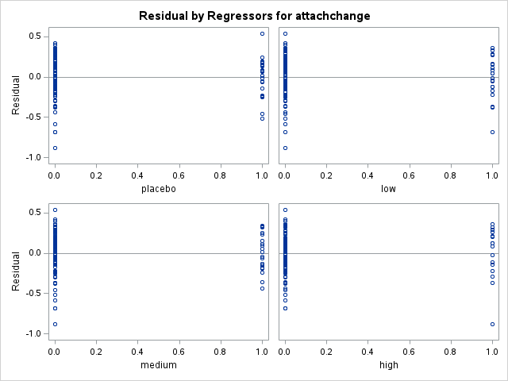

**log**

```
51                                                         The SAS System                      Friday, December 19, 2025 03:16:00 AM

531        ods listing close;ods html5 (id=saspy_internal) file=_tomods1 options(bitmap_mode='inline') device=svg style=HTMLBlue;
531      ! ods graphics on / outputfmt=png;
532
533        * Run regression of attachment loss by treatment condition with control as reference;
534        TITLE "SLR of Attachment Loss Change by Treatment Condition - Control as Reference";
535        PROC REG DATA = Proj1.data;
536         MODEL attachchange = placebo low medium high;
537         RUN;
538
539
540        ods html5 (id=saspy_internal) close;ods listing;
541
52                                                         The SAS System                      Friday, December 19, 2025 03:16:00 AM

542
```

#### Interpretation

The overall model is significant (F<sub>(4,98)</sub> = 2.53, p = 0.0451). Looking at the individual t-statistics, we see that - following adjustment for multiple pairwise comparisons - the placebo group (p = 0.549), low concentration group (p = 0.0668), and high concentration group (p = 1.000) are not statistically different from the control group. The medium concentration group is approaching significance (p = 0.0503).

#### Change Reference to Placebo Group

That was with the no treatment control group as the reference. Let’s see if any of our treatment conditions were different from the placebo group.

```sas
TITLE "SLR of Attachment Loss Change by Treatment Condition - Placebo as Reference";
PROC REG DATA = Proj1.data;
    MODEL attachchange = control low medium high;
    RUN;
```

**lst**

<!DOCTYPE html>

SLR of Attachment Loss Change by Treatment Condition - Placebo as Reference

The REG Procedure

Model: MODEL1

Dependent Variable: attachchange Attachment Loss Change

| Number of Observations Read | 130 |
| --- | --- |
| Number of Observations Used | 103 |
| Number of Observations with Missing Values | 27 |

| Analysis of Variance Source | Analysis of Variance DF | Analysis of Variance Sum of Squares | Analysis of Variance Mean Square | Analysis of Variance F Value | Analysis of Variance Pr > F |
| --- | --- | --- | --- | --- | --- |
| Model | 4 | 0.72806 | 0.18202 | 2.53 | 0.0451 |
| Error | 98 | 7.04360 | 0.07187 |  |  |
| Corrected Total | 102 | 7.77166 |  |  |  |

| Root MSE | 0.26809 | R-Square | 0.0937 |
| --- | --- | --- | --- |
| Dependent Mean | -0.09945 | Adj R-Sq | 0.0567 |
| Coeff Var | -269.57211 |  |  |

| Parameter Estimates Variable | Parameter Estimates Label | Parameter Estimates DF | Parameter Estimates Parameter Estimate | Parameter Estimates Standard Error | Parameter Estimates t Value | Parameter Estimates Pr > \|t\| |
| --- | --- | --- | --- | --- | --- | --- |
| Intercept | Intercept | 1 | -0.08707 | 0.05590 | -1.56 | 0.1225 |
| control |  | 1 | -0.13462 | 0.07906 | -1.70 | 0.0918 |
| low |  | 1 | 0.06926 | 0.08092 | 0.86 | 0.3941 |
| medium |  | 1 | 0.08052 | 0.08197 | 0.98 | 0.3284 |
| high |  | 1 | -0.07772 | 0.08728 | -0.89 | 0.3754 |

SLR of Attachment Loss Change by Treatment Condition - Placebo as Reference

The REG Procedure

Model: MODEL1

Dependent Variable: attachchange Attachment Loss Change

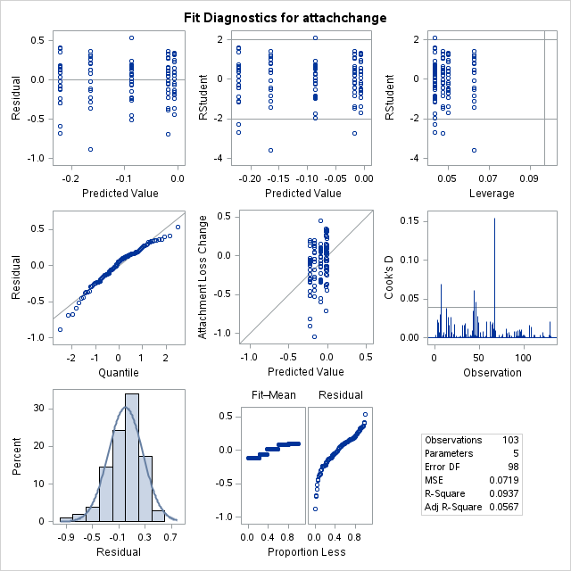

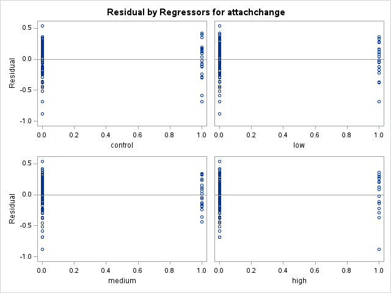

**log**

```
53                                                         The SAS System                      Friday, December 19, 2025 03:16:00 AM

545        ods listing close;ods html5 (id=saspy_internal) file=_tomods1 options(bitmap_mode='inline') device=svg style=HTMLBlue;
545      ! ods graphics on / outputfmt=png;
546
547        TITLE "SLR of Attachment Loss Change by Treatment Condition - Placebo as Reference";
548        PROC REG DATA = Proj1.data;
549         MODEL attachchange = control low medium high;
550         RUN;
551
552
553        ods html5 (id=saspy_internal) close;ods listing;
554
54                                                         The SAS System                      Friday, December 19, 2025 03:16:00 AM

555
```

After applying a bonferroni correction, none of the groups are significantly different from the placebo group (p > .05).

#### Conclusion

While the overall model was significant, the only groups that were statistically different from the no treatment control were the low and medium concentration gel groups (p < 0.05). However, since this was a placebo-controlled RCT, and none of the treatment groups were significantly different from the placebo group, we can conclude that we *fail to reject the null hypothesis* that the average attachment loss over 1 year is the same between all groups.

Back to top of tabset

**Pocket Depth Change**

Now we will create our model with pocket depth change as the dependent variable and treatment group as the independent variable.

```sas
* Simple Linear Regression Predicting Pocket Depth Change by Treatment Condition;
TITLE "SLR of Pocket Depth Change by Treatment Condition - Control as Reference";
PROC REG DATA = Proj1.data;
    MODEL pdchange = placebo low medium high;
    RUN;
```

**lst**

<!DOCTYPE html>

SLR of Pocket Depth Change by Treatment Condition - Control as Reference

The REG Procedure

Model: MODEL1

Dependent Variable: pdchange Pocket Depth Change

| Number of Observations Read | 130 |
| --- | --- |
| Number of Observations Used | 103 |
| Number of Observations with Missing Values | 27 |

| Analysis of Variance Source | Analysis of Variance DF | Analysis of Variance Sum of Squares | Analysis of Variance Mean Square | Analysis of Variance F Value | Analysis of Variance Pr > F |
| --- | --- | --- | --- | --- | --- |
| Model | 4 | 0.57020 | 0.14255 | 2.07 | 0.0899 |
| Error | 98 | 6.73457 | 0.06872 |  |  |
| Corrected Total | 102 | 7.30477 |  |  |  |

| Root MSE | 0.26215 | R-Square | 0.0781 |
| --- | --- | --- | --- |
| Dependent Mean | -0.29435 | Adj R-Sq | 0.0404 |
| Coeff Var | -89.05770 |  |  |

| Parameter Estimates Variable | Parameter Estimates Label | Parameter Estimates DF | Parameter Estimates Parameter Estimate | Parameter Estimates Standard Error | Parameter Estimates t Value | Parameter Estimates Pr > \|t\| |
| --- | --- | --- | --- | --- | --- | --- |
| Intercept | Intercept | 1 | -0.33817 | 0.05466 | -6.19 | <.0001 |
| placebo |  | 1 | -0.01152 | 0.07730 | -0.15 | 0.8818 |
| low |  | 1 | 0.13200 | 0.07912 | 1.67 | 0.0984 |
| medium |  | 1 | 0.13562 | 0.08015 | 1.69 | 0.0938 |
| high |  | 1 | -0.04413 | 0.08534 | -0.52 | 0.6063 |

SLR of Pocket Depth Change by Treatment Condition - Control as Reference

The REG Procedure

Model: MODEL1

Dependent Variable: pdchange Pocket Depth Change

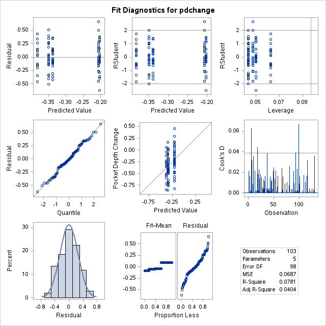

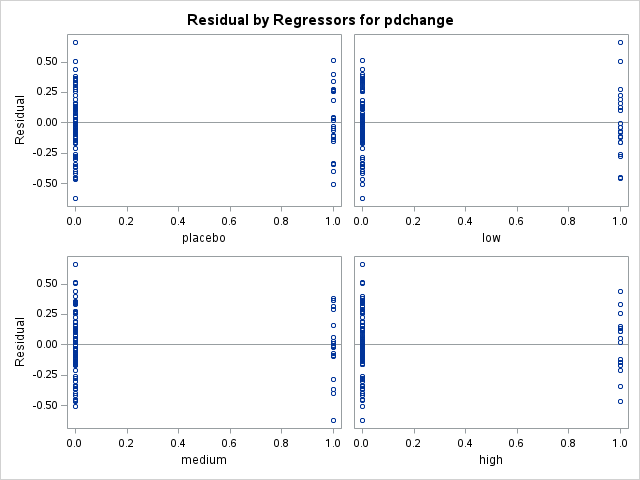

**log**

```
55                                                         The SAS System                      Friday, December 19, 2025 03:16:00 AM

558        ods listing close;ods html5 (id=saspy_internal) file=_tomods1 options(bitmap_mode='inline') device=svg style=HTMLBlue;
558      ! ods graphics on / outputfmt=png;
559
560        * Simple Linear Regression Predicting Pocket Depth Change by Treatment Condition;
561        TITLE "SLR of Pocket Depth Change by Treatment Condition - Control as Reference";
562        PROC REG DATA = Proj1.data;
563         MODEL pdchange = placebo low medium high;
564         RUN;
565
566
567        ods html5 (id=saspy_internal) close;ods listing;
568
56                                                         The SAS System                      Friday, December 19, 2025 03:16:00 AM

569
```

The overall model is not statistically significant (F<sub>(4,98)</sub>= 2.074, p = 0.0899). Based on this model, it appears that the gel treatment has no effect on pocket depth change after 1 year.

Back to top of tabset

**Post-Hoc Analysis**

We did not find a main effect based on treatment group. However I am still interested if including any of the covariates changes the results.

#### Model Including Gender

```sas
* Try a model of attachment loss change by treatment condition, controlling for gender;
TITLE "MLR of Attachment Loss Change by Treatment Condition and Gender";
PROC REG DATA = Proj1.data;
    MODEL attachchange = placebo low medium high gender;
    RUN;
```

**lst**

<!DOCTYPE html>

MLR of Attachment Loss Change by Treatment Condition and Gender

The REG Procedure

Model: MODEL1

Dependent Variable: attachchange Attachment Loss Change

| Number of Observations Read | 130 |
| --- | --- |
| Number of Observations Used | 103 |
| Number of Observations with Missing Values | 27 |

| Analysis of Variance Source | Analysis of Variance DF | Analysis of Variance Sum of Squares | Analysis of Variance Mean Square | Analysis of Variance F Value | Analysis of Variance Pr > F |
| --- | --- | --- | --- | --- | --- |
| Model | 5 | 0.89852 | 0.17970 | 2.54 | 0.0335 |
| Error | 97 | 6.87314 | 0.07086 |  |  |
| Corrected Total | 102 | 7.77166 |  |  |  |

| Root MSE | 0.26619 | R-Square | 0.1156 |
| --- | --- | --- | --- |
| Dependent Mean | -0.09945 | Adj R-Sq | 0.0700 |
| Coeff Var | -267.65934 |  |  |

| Parameter Estimates Variable | Parameter Estimates Label | Parameter Estimates DF | Parameter Estimates Parameter Estimate | Parameter Estimates Standard Error | Parameter Estimates t Value | Parameter Estimates Pr > \|t\| |
| --- | --- | --- | --- | --- | --- | --- |
| Intercept | Intercept | 1 | -0.07460 | 0.10988 | -0.68 | 0.4988 |
| placebo |  | 1 | 0.12330 | 0.07883 | 1.56 | 0.1210 |
| low |  | 1 | 0.19310 | 0.08064 | 2.39 | 0.0186 |
| medium |  | 1 | 0.21118 | 0.08143 | 2.59 | 0.0110 |
| high |  | 1 | 0.06704 | 0.08690 | 0.77 | 0.4423 |
| gender | Gender | 1 | -0.08675 | 0.05593 | -1.55 | 0.1242 |

MLR of Attachment Loss Change by Treatment Condition and Gender

The REG Procedure

Model: MODEL1

Dependent Variable: attachchange Attachment Loss Change

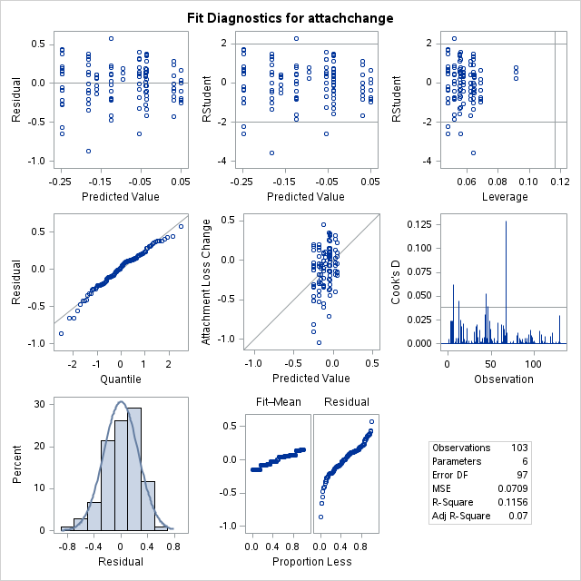

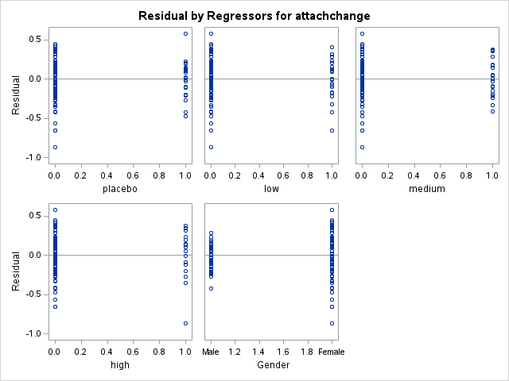

**log**

```
57                                                         The SAS System                      Friday, December 19, 2025 03:16:00 AM

572        ods listing close;ods html5 (id=saspy_internal) file=_tomods1 options(bitmap_mode='inline') device=svg style=HTMLBlue;
572      ! ods graphics on / outputfmt=png;
573
574        * Try a model of attachment loss change by treatment condition, controlling for gender;
575        TITLE "MLR of Attachment Loss Change by Treatment Condition and Gender";
576        PROC REG DATA = Proj1.data;
577         MODEL attachchange = placebo low medium high gender;
578         RUN;
579
580
581        ods html5 (id=saspy_internal) close;ods listing;
582
58                                                         The SAS System                      Friday, December 19, 2025 03:16:00 AM

583
```

A model including gender does not seem to help anything. What about with all covariates?